# Exploratory Data Analysis in R

Greg Chism

3/28/2022

## Purpose of workshop

**Exploring and visualizing a novel data set and produce publication quality graphs and tables**

## Objectives

1. Load and explore a data set with publication quality tables
2. Visualize the data with publication quality figures
3. Understand regression analyses

#### Required setup

We first need to prepare our environment with the necessary packages and set a global theme for publishable plots in ggplot()

```r
options(repos = list(CRAN = "http://cran.rstudio.com/"))
options(digits = 2)

install.packages("pacman")
pacman::p_load(dlookr,
       formattable,
       ggdist,
       ggpubr,
       ggridges,
       kableExtra,
       knitr,
       palmerpenguins,
       papeR,
       RColorBrewer,
       Stat2Data,
       tidyverse)

theme_set(theme_pubr())
```

### 1.0 Load and examine a data set

- Load data and view
- Examine columns and data types
- Define box plots
- Describe meta data

```r
# Let's load a data set from the Hawks data set
data("Hawks")

# What does the data look like?
formattable(head(Hawks))
```

| Month | Day | Year | CaptureTime | ReleaseTime | BandNumber | Species | Age | Sex | Wing | Weight | Culmen | Hallux | Tail | StandardTail | Tarsus | WingPitFat | KeelFat | Crop |
| --- | --- | --- | --- | --- | --- | --- | --- | --- | --- | --- | --- | --- | --- | --- | --- | --- | --- | --- |
| 9 | 19 | 1992 | 13:30 |  | 877-76317 | RT | I |  | 385 | 920 | 26 | 30 | 219 | NA | NA | NA | NA | NA |
| 9 | 22 | 1992 | 10:30 |  | 877-76318 | RT | I |  | 376 | 930 | NA | NA | 221 | NA | NA | NA | NA | NA |
| 9 | 23 | 1992 | 12:45 |  | 877-76319 | RT | I |  | 381 | 990 | 27 | 31 | 235 | NA | NA | NA | NA | NA |
| 9 | 23 | 1992 | 10:50 |  | 745-49508 | CH | I | F | 265 | 470 | 19 | 24 | 220 | NA | NA | NA | NA | NA |
| 9 | 27 | 1992 | 11:15 |  | 1253-98801 | SS | I | F | 205 | 170 | 12 | 14 | 157 | NA | NA | NA | NA | NA |
| 9 | 28 | 1992 | 11:25 |  | 1207-55910 | RT | I |  | 412 | 1090 | 28 | 32 | 230 | NA | NA | NA | NA | NA |

#### 1.1 Diagnose your data

```r
# What are the properties of the data
formattable(diagnose(Hawks))
```

| variables | types | missing_count | missing_percent | unique_count | unique_rate |
| --- | --- | --- | --- | --- | --- |
| Month | integer | 0 | 0.00 | 4 | 0.0044 |
| Day | integer | 0 | 0.00 | 31 | 0.0341 |
| Year | integer | 0 | 0.00 | 12 | 0.0132 |
| CaptureTime | factor | 0 | 0.00 | 308 | 0.3392 |
| ReleaseTime | factor | 0 | 0.00 | 60 | 0.0661 |
| BandNumber | factor | 0 | 0.00 | 907 | 0.9989 |
| Species | factor | 0 | 0.00 | 3 | 0.0033 |
| Age | factor | 0 | 0.00 | 2 | 0.0022 |
| Sex | factor | 0 | 0.00 | 3 | 0.0033 |
| Wing | numeric | 1 | 0.11 | 185 | 0.2037 |
| Weight | integer | 10 | 1.10 | 308 | 0.3392 |
| Culmen | numeric | 7 | 0.77 | 180 | 0.1982 |
| Hallux | numeric | 6 | 0.66 | 207 | 0.2280 |
| Tail | integer | 0 | 0.00 | 128 | 0.1410 |
| StandardTail | integer | 337 | 37.11 | 119 | 0.1311 |
| Tarsus | numeric | 833 | 91.74 | 68 | 0.0749 |
| WingPitFat | integer | 831 | 91.52 | 5 | 0.0055 |
| KeelFat | numeric | 341 | 37.56 | 9 | 0.0099 |
| Crop | numeric | 343 | 37.78 | 12 | 0.0132 |

- `variables`: name of each variable
- `types`: data type of each variable
- `missing_count`: number of missing values
- `missing_percent`: percentage of missing values
- `unique_count`: number of unique values
- `unique_rate`: rate of unique value - unique_count / number of observations

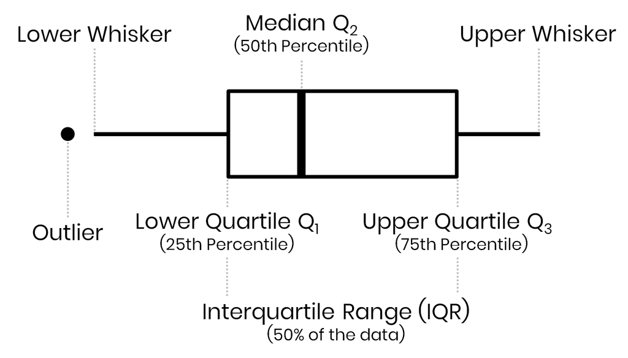

*Credit to Cédric Scherer*

#### 1.2 Summary statistics of your data

##### Numerical variables

```r
formattable(diagnose_numeric(Hawks))
```

| variables | min | Q1 | mean | median | Q3 | max | zero | minus | outlier |
| --- | --- | --- | --- | --- | --- | --- | --- | --- | --- |
| Month | 8.0 | 9 | 9.84 | 10 | 10.00 | 11 | 0 | 0 | 0 |
| Day | 1.0 | 9 | 15.74 | 16 | 23.00 | 31 | 0 | 0 | 0 |
| Year | 1992.0 | 1995 | 1998.25 | 1999 | 2001.00 | 2003 | 0 | 0 | 0 |
| Wing | 37.2 | 202 | 315.64 | 370 | 390.00 | 480 | 0 | 0 | 0 |
| Weight | 56.0 | 185 | 772.08 | 970 | 1120.00 | 2030 | 0 | 0 | 0 |
| Culmen | 8.6 | 13 | 21.80 | 26 | 27.30 | 39 | 0 | 0 | 0 |
| Hallux | 9.5 | 15 | 26.41 | 29 | 31.40 | 341 | 0 | 0 | 7 |
| Tail | 119.0 | 160 | 198.83 | 214 | 225.00 | 288 | 0 | 0 | 0 |
| StandardTail | 115.0 | 162 | 199.18 | 215 | 226.00 | 335 | 0 | 0 | 1 |
| Tarsus | 24.7 | 56 | 71.95 | 79 | 87.00 | 94 | 0 | 0 | 0 |
| WingPitFat | 0.0 | 0 | 0.79 | 1 | 1.00 | 3 | 36 | 0 | 3 |
| KeelFat | 0.0 | 2 | 2.18 | 2 | 3.00 | 4 | 35 | 0 | 35 |
| Crop | 0.0 | 0 | 0.23 | 0 | 0.25 | 5 | 370 | 0 | 84 |

- `min`: minimum value
- `Q1`: 1/4 quartile, 25th percentile
- `mean`: arithmetic mean (average value)
- `median`: median, 50th percentile
- `Q3`: 3/4 quartile, 75th percentile
- `max`: maximum value
- `zero`: number of observations with the value 0
- `minus`: number of observations with negative numbers
- `outlier`: number of outliers

##### Outliers

There are several numerical variables that have outliers above, let’s see what the data look like with and without them * Create a table with columns containing outliers * Plot outliers in a box plot and histogram

```r
# Table showing outliers
formattable(diagnose_outlier(Hawks) %>%
  filter(outliers_ratio > 0))
```

| variables | outliers_cnt | outliers_ratio | outliers_mean | with_mean | without_mean |
| --- | --- | --- | --- | --- | --- |
| Hallux | 7 | 0.77 | 175.3 | 26.41 | 25.246 |
| StandardTail | 1 | 0.11 | 335.0 | 199.18 | 198.944 |
| WingPitFat | 3 | 0.33 | 3.0 | 0.79 | 0.703 |
| KeelFat | 35 | 3.85 | 0.0 | 2.18 | 2.328 |
| Crop | 84 | 9.25 | 1.1 | 0.23 | 0.082 |

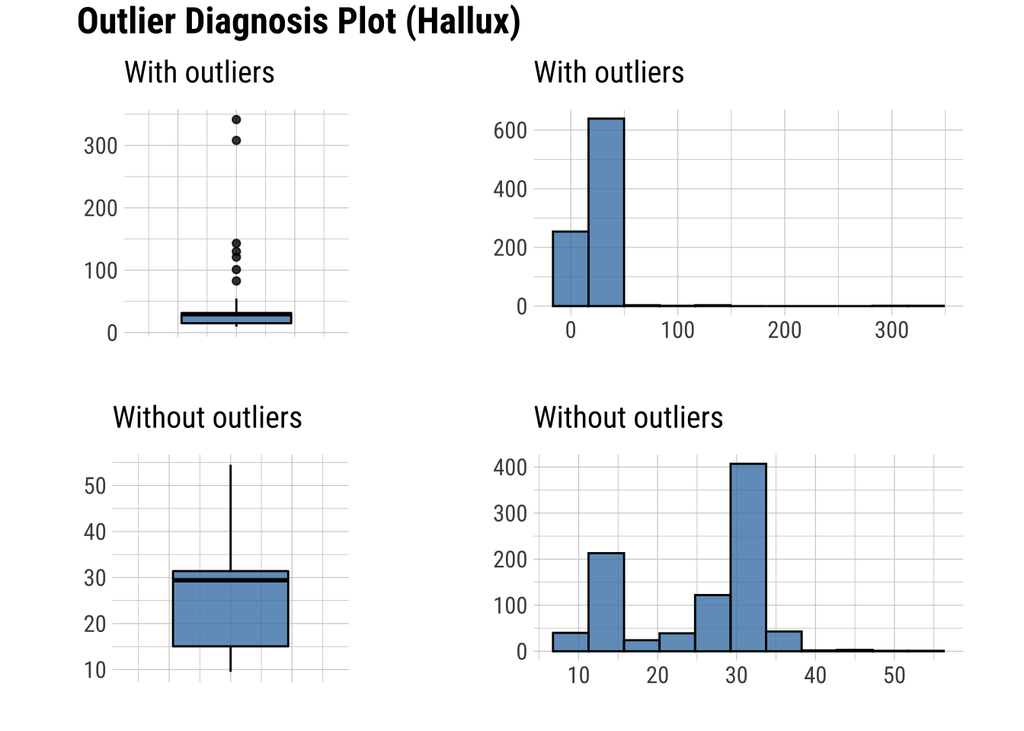

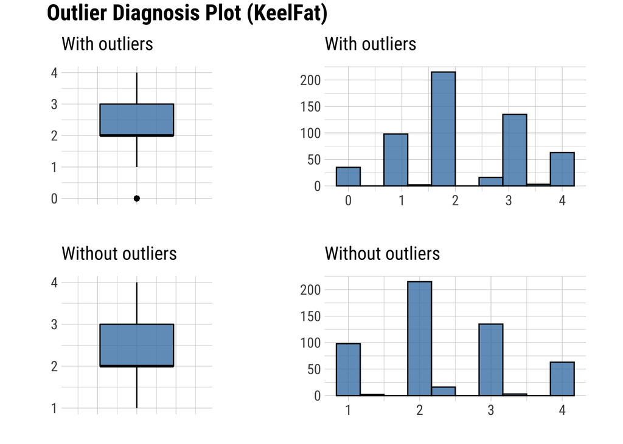

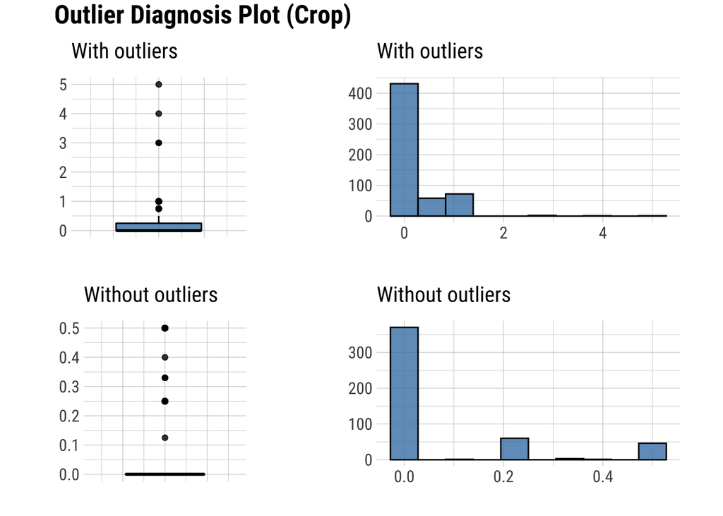

```r
# Boxplot and histograms of data with and without outliers
Hawks %>%
  select(find_outliers(Hawks)) %>%
           plot_outlier()
```

##### Categorical variables

```r
formattable(diagnose_category(Hawks))
```

| variables | levels | N | freq | ratio | rank |
| --- | --- | --- | --- | --- | --- |
| CaptureTime | 11:35 | 908 | 14 | 1.54 | 1 |
| CaptureTime | 13:30 | 908 | 14 | 1.54 | 1 |
| CaptureTime | 11:45 | 908 | 13 | 1.43 | 3 |
| CaptureTime | 12:10 | 908 | 13 | 1.43 | 3 |
| CaptureTime | 14:00 | 908 | 13 | 1.43 | 3 |
| CaptureTime | 13:05 | 908 | 12 | 1.32 | 6 |
| CaptureTime | 11:00 | 908 | 11 | 1.21 | 7 |
| CaptureTime | 12:15 | 908 | 11 | 1.21 | 7 |
| CaptureTime | 13:35 | 908 | 11 | 1.21 | 7 |
| CaptureTime | 10:45 | 908 | 10 | 1.10 | 10 |
| ReleaseTime |  | 908 | 842 | 92.73 | 1 |
| ReleaseTime | 11:00 | 908 | 2 | 0.22 | 2 |
| ReleaseTime | 11:35 | 908 | 2 | 0.22 | 2 |
| ReleaseTime | 12:05 | 908 | 2 | 0.22 | 2 |
| ReleaseTime | 12:50 | 908 | 2 | 0.22 | 2 |
| ReleaseTime | 13:32 | 908 | 2 | 0.22 | 2 |
| ReleaseTime | 14:45 | 908 | 2 | 0.22 | 2 |
| ReleaseTime | 14:50 | 908 | 2 | 0.22 | 2 |
| ReleaseTime |  | 908 | 1 | 0.11 | 9 |
| ReleaseTime | 10:20 | 908 | 1 | 0.11 | 9 |
| BandNumber |  | 908 | 2 | 0.22 | 1 |
| BandNumber | 1142-09240 | 908 | 1 | 0.11 | 2 |
| BandNumber | 1142-09241 | 908 | 1 | 0.11 | 2 |
| BandNumber | 1142-09242 | 908 | 1 | 0.11 | 2 |
| BandNumber | 1142-18229 | 908 | 1 | 0.11 | 2 |
| BandNumber | 1142-19209 | 908 | 1 | 0.11 | 2 |
| BandNumber | 1142-19210 | 908 | 1 | 0.11 | 2 |
| BandNumber | 1142-19211 | 908 | 1 | 0.11 | 2 |
| BandNumber | 1142-19212 | 908 | 1 | 0.11 | 2 |
| BandNumber | 1142-19213 | 908 | 1 | 0.11 | 2 |
| Species | RT | 908 | 577 | 63.55 | 1 |
| Species | SS | 908 | 261 | 28.74 | 2 |
| Species | CH | 908 | 70 | 7.71 | 3 |
| Age | I | 908 | 684 | 75.33 | 1 |
| Age | A | 908 | 224 | 24.67 | 2 |
| Sex |  | 908 | 576 | 63.44 | 1 |
| Sex | F | 908 | 174 | 19.16 | 2 |
| Sex | M | 908 | 158 | 17.40 | 3 |

- `variables`: category names
- `levels`: group names within categories
- `N`: number of observation
- `freq`: number of observation at group level / number of observation at category level
- `ratio`: percentage of observation at group level / number of observation at category level
- `rank`: rank of the occupancy ratio of levels (order in which the groups are in the category)

##### Missing values (NAs)

- Table showing the extent of NAs in columns containing them
- Plot showing the frequency of missing values

```r
# Create the NA table
NA.Table <- plot_na_pareto(Hawks, only_na = TRUE, plot = FALSE)

# Publishable table
formattable(NA.Table)
```

| variable | frequencies | ratio | grade | cumulative |
| --- | --- | --- | --- | --- |
| Tarsus | 833 | 0.9174 | Remove | 31 |
| WingPitFat | 831 | 0.9152 | Remove | 61 |
| Crop | 343 | 0.3778 | Bad | 74 |
| KeelFat | 341 | 0.3756 | Bad | 87 |
| StandardTail | 337 | 0.3711 | Bad | 99 |
| Weight | 10 | 0.0110 | Good | 99 |
| Culmen | 7 | 0.0077 | Good | 100 |
| Hallux | 6 | 0.0066 | Good | 100 |
| Wing | 1 | 0.0011 | Good | 100 |

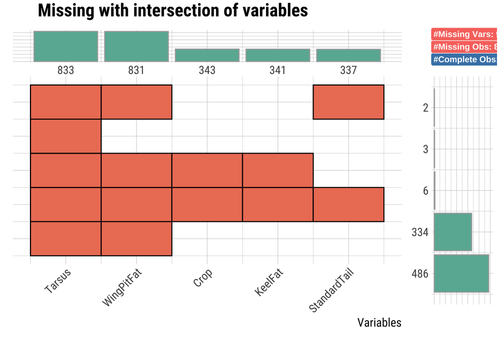

```r
# Plot the insersect of the 5 columns with the most missing values
# This means that some combinations of columns have missing values in the same row
plot_na_intersect(Hawks, only_na = TRUE, n_vars = 5, n_intersacts = 5)
```

### 2.0 Visualize the data with publication quality figures

- Relationships among groups - i.e., species
- Relationships between continuous variables - i.e., wing and tail length

#### 2.1 Plotting relationships among groups

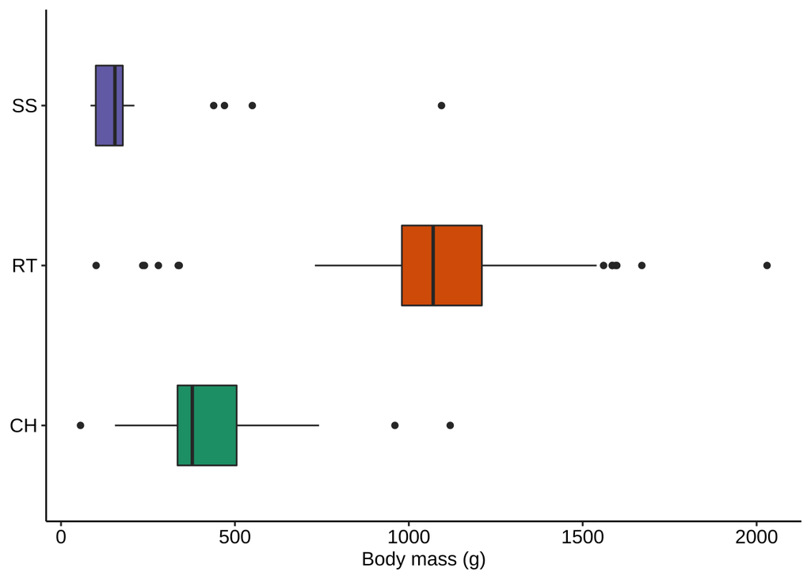

```r
# Now let's explore some of the data
# you can use several methods to visualize groups:

# Box plot
Hawks %>% # Set the simulated normal data as a data frame
  ggplot(aes(x = Weight, y = Species, fill = Species)) + # Create a ggplot
  geom_boxplot(width = 0.5) +
  xlab("Body mass (g)") +  # Remove the x axis label
  ylab(NULL) + # Remove the y axis label
  scale_fill_brewer(palette = "Dark2") + # Change the color scheme for the fill criteria
  theme(legend.position = "none") # Remove the legend
```

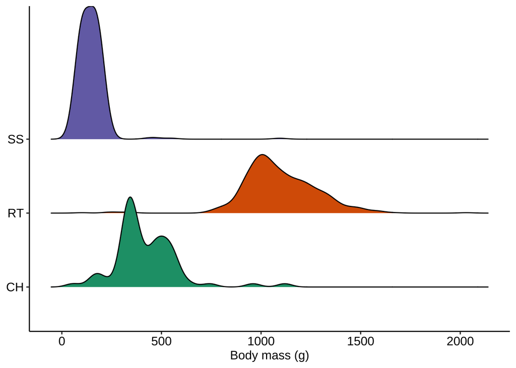

```r
# Ridge plots (basically density plots)
Hawks %>% # Set the simulated normal data as a data frame
  ggplot(aes(x = Weight, y = Species, fill = Species)) + # Create a ggplot
  geom_density_ridges() +
  xlab("Body mass (g)") + # Change x axis label
  ylab(NULL) + # Remove the y axis label
  scale_fill_brewer(palette = "Dark2") + # Change the color scheme for the fill criteria
  theme(legend.position = "none") # Remove the legend
```

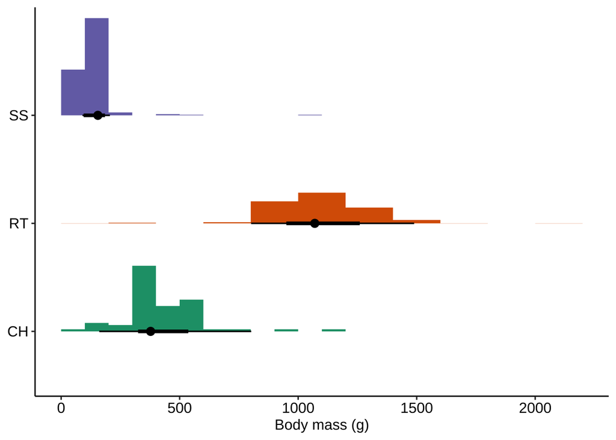

```r
# Histogram interval plot
Hawks %>% # Set the simulated normal data as a data frame
  ggplot(aes(x = Species, y = Weight, fill = Species)) + # Create a ggplot
  # Add a histogram and interval plot
  stat_histinterval() + # Color the histogram bins
  # Remove the x axis label
  xlab(NULL) + # Remove the x axis label
  # Change y axis label
  ylab("Body mass (g)") + # Change y axis label
  coord_flip() +
  scale_fill_brewer(palette = "Dark2") +
  theme(legend.position = "none")
```

#### 2.2 Plotting relationships between continuous variables

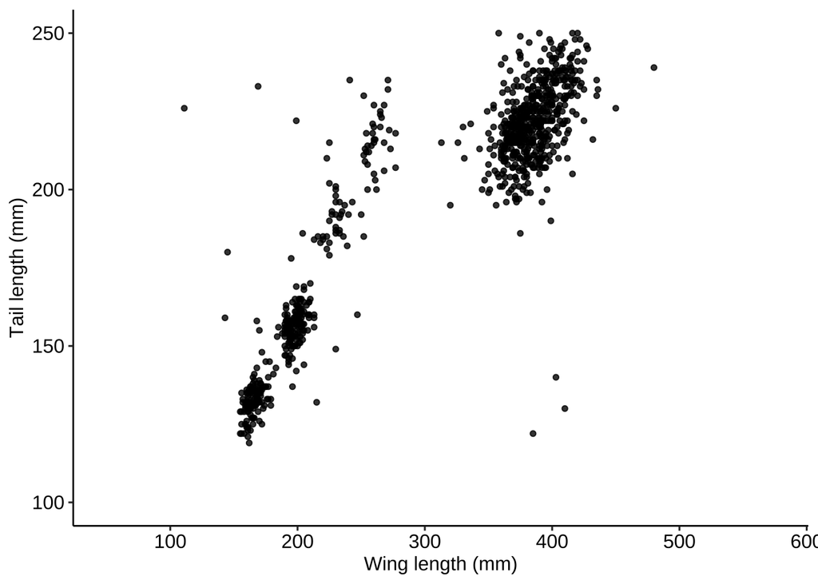

```r
# We plot relationships between continuous variables several ways

# SCATTER PLOTS
# Basic scatter plot
Hawks %>%
  ggplot(aes(x = Wing, y = Tail)) + # Create a ggplot
  # Scatter plot, change size to 1.3, change transparency to 0.8
  geom_point(size = 1.3, alpha = 0.8) +
  xlab("Wing length (mm)") + # Change x axis label
  ylab("Tail length (mm)") + # Change y axis label
  xlim(50, 575) +
  ylim(100, 250)
```

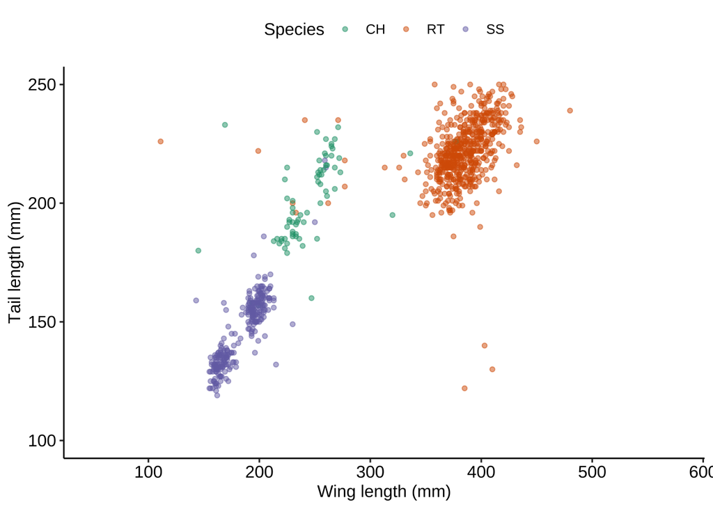

```r
# Grouped scatter plot
Hawks %>%
  ggplot(aes(x = Wing, y = Tail, color = Species)) + # Create a ggplot
  geom_point(size = 1.3, alpha = 0.5) +
  # Change y axis label
  xlab("Wing length (mm)") + # Change x axis label
  ylab("Tail length (mm)") + # Change y axis label
  scale_color_brewer(palette = "Dark2") +
  labs(color = "Species") + # Change the label of the legend
  xlim(50, 575) +
  ylim(100, 250)
```

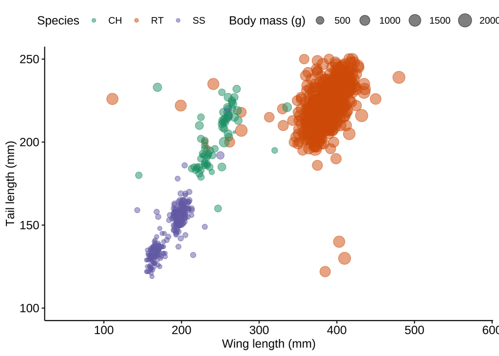

```r
# Scatter plot with scaled point size
Hawks %>%
  ggplot(aes(x = Wing, y = Tail, color = Species, size = Weight)) + # Create a ggplot
  geom_point(alpha = 0.5) +
  xlab("Wing length (mm)") + # Change x axis label
  ylab("Tail length (mm)") + # Change y axis label
  scale_color_brewer(palette = "Dark2") +
  labs(color = "Species", size = "Body mass (g)") + # Change the label of the legend
  xlim(50, 575) +
  ylim(100, 250)
```

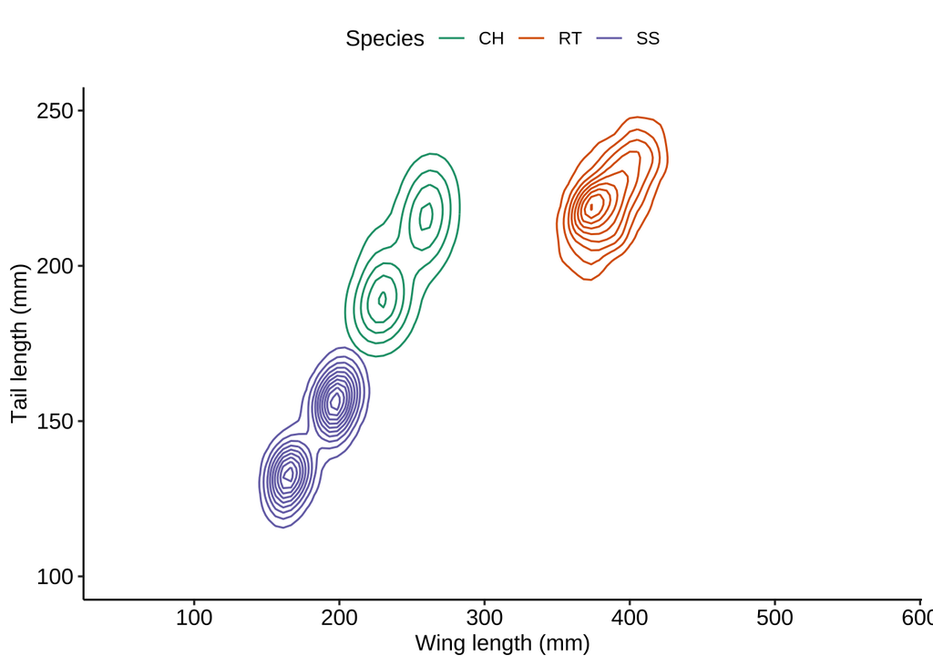

```r
# Density plots
# Contours
Hawks %>%
  ggplot(aes(x = Wing, y = Tail, color = Species)) + # Create a ggplot
  # Density contour plot
  geom_density_2d() +
  xlab("Wing length (mm)") + # Change x axis label
  ylab("Tail length (mm)") + # Change y axis label
  scale_color_brewer(palette = "Dark2") +
  labs(color = "Species") + # Change the label of the legend
  xlim(50, 575) +
  ylim(100, 250)
```

### 3.0 Understanding regression analysis

- Run a linear regression (lm()): the relationship between hawk wing and tail length
- Clean the summary() output using prettify()
- Produce a publishable table using kable() and kable_styling

```r
# Simple linear regression predicting the relationship between wing and tail length in hawks
LinMod <- summary(lm(Tail ~ Wing, data = Hawks))

# Clean the summary() output using prettify()
Pretty_lm <- prettify(LinMod)

# Create an HTML table using kable, where the prettify() function cleans the raw summary output and the kable_styling() applies a clean theme
kable(Pretty_lm) %>%
  kable_styling()
```

|  | Estimate | CI (lower) | CI (upper) | Std. Error | t value | Pr(>\|t\|) |  |
| --- | --- | --- | --- | --- | --- | --- | --- |
| (Intercept) | 88.97 | 85.35 | 92.60 | 1.85 | 48 | <0.001 | *** |
| Wing | 0.35 | 0.34 | 0.36 | 0.01 | 62 | <0.001 | *** |

`CI (lower & upper)`

- 95% statistical confidence intervals that the true population value for the estimate is between these values - i.e., the estimate calculated from wing length is between 0.34mm and 0.36mm.

`Standard Error`

- The average amount that the coefficient estimates vary from our response variable - i.e., if you ran the model several times the estimate calculated for wing length would vary 0.01mm.

`t-value`

- How many standard deviations does the coefficient estimate deviate from 0.
- Large *t-values* are important towards rejecting the null hypothesis - i.e., the estimate for wing length is 62 std. deviations from 0.

#### 3.1 Plotting a linear regression

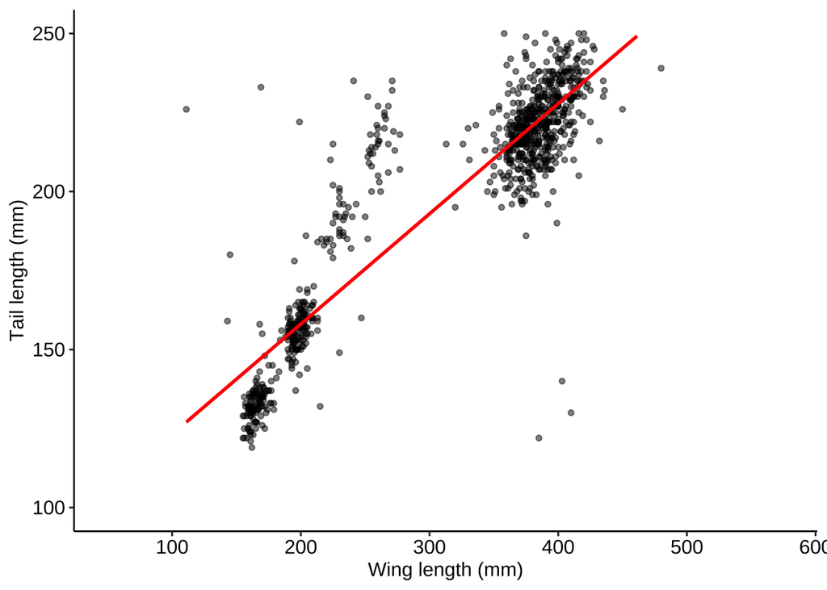

```r
# Plotting the linear relationship between wing and tail length in hawks
Hawks %>%
  ggplot(aes(x = Wing, y = Tail)) + # Create a ggplot
  # Scatter plot, change size to 1.3, change transparency to 0.8
  geom_point(size = 1.3, alpha = 0.5) +
  geom_smooth(method = "lm", color = "red", se = FALSE) +
  xlab("Wing length (mm)") + # Change x axis label
  ylab("Tail length (mm)") + # Change y axis label
  xlim(50, 575) +
  ylim(100, 250)
```

#### 3.2 Multiple regression

- Multiple linear regression analysis examining how hawk species affects the relationship between wing and tail length

```r
# Multiple linear regression predicting the relationship between wing and tail length in hawks
LinMod <- summary(lm(Tail ~ Wing * Species, data = Hawks))

# Clean the summary() output using prettify()
Pretty_lm <- prettify(LinMod)

# Create an HTML table using kable, where the prettify() function cleans the raw summary output and the kable_styling() applies a clean theme
kable(Pretty_lm) %>%
  kable_styling()
```

|  | Estimate | CI (lower) | CI (upper) | Std. Error | t value | Pr(>\|t\|) |  |
| --- | --- | --- | --- | --- | --- | --- | --- |
| (Intercept) | 126.85 | 104.13 | 149.56 | 11.57 | 11.0 | <0.001 | *** |
| Wing | 0.30 | 0.21 | 0.40 | 0.05 | 6.5 | <0.001 | *** |
| Species: RT | 38.71 | 12.81 | 64.61 | 13.20 | 2.9 | 0.003 | ** |
| Species: SS | -92.85 | -118.82 | -66.87 | 13.23 | -7.0 | <0.001 | *** |
| Wing:SpeciesRT | -0.16 | -0.25 | -0.06 | 0.05 | -3.1 | 0.002 | ** |
| Wing:SpeciesSS | 0.31 | 0.19 | 0.42 | 0.06 | 5.2 | <0.001 | *** |

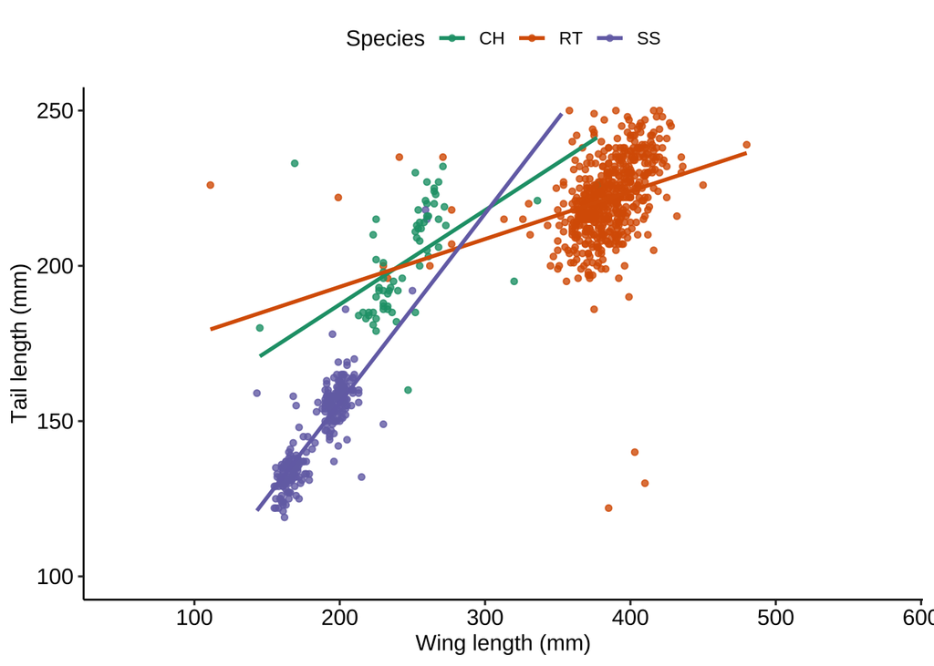

```r
# Plotting the multiple regression
Hawks %>%
  ggplot(aes(x = Wing, y = Tail)) + # Create a ggplot
  # Scatter plot, change size to 1.3, change transparency to 0.8
  geom_point(aes(color = Species), size = 1.3, alpha = 0.8) +
  geom_smooth(aes(color = Species), method = "lm", se = FALSE) +
  xlab("Wing length (mm)") + # Change x axis label
  ylab("Tail length (mm)") + # Change y axis label
  scale_color_brewer(palette = "Dark2") +
  labs(color = "Species") +
  xlim(50, 575) +
  ylim(100, 250)
```